# Classification of Cancer Types From Tissue Microarray Gene Expression

### Andy Wang, Sylvain Yabre, Karen Li

The fundamental biology of cancer is characterized by progressive and accumulated mutations that lead to the degeneration of cellular checks and balances controlling cell proliferation, entrance to the cell cycle, and programmed cell death. However, while the inherent patterns of cancer cell formation follows this general pattern, there are signifcant cell-type to cell-type variations that affect clinical outcomes and prognoses. Our project therefore investigates the differences in gene expression among cancers of various tissue origin.

Our dataset comes from "The Human Protein Atlas", a Swedish project that aims to categorize all human proteins via the use of various 'omics' methods, which are experiments that can give a global picture of one aspect of cell biology, such as its RNA profile, histone configurations, or protein phosphorylation. In our dataset, the omics approach used is proteomics, specifically immunohistochemisty microarrays. Patient cancer cells of known tissue origins (ie breast cancer, lymphoma, glioma etc) are taken and the sample follows a pipeline.

Immunohistochemistry microarrays use antibodies to detect the presence of specific epitopes within a cell. Antibodies can be raised (ie designed) to be specific for a particular protein or other biological substance. The power of this approach comes from the 'vectorization' of protein detection, where thousands of different antibodies can be applied to the same sample at the same time in order to form a pattern of protein or gene expression level of the whole sample. Let's take a look at our specific dataset [Cancer Tumor Data](https://v15.proteinatlas.org/about/download).

```python
pip install -U scikit-learn
```

```python
import pandas as pd
import numpy as np
import matplotlib.pyplot as plt
import seaborn as sns
%matplotlib inline
from sklearn.ensemble import IsolationForest
from sklearn.svm import OneClassSVM
from sklearn.model_selection import cross_val_score
from sklearn.model_selection import cross_val_predict
from sklearn.metrics import accuracy_score, classification_report
from sklearn.model_selection import train_test_split
import tensorflow as tf
from tensorflow.keras.models import Sequential
from tensorflow.keras.layers import Dense
from tensorflow import keras
```

```python
url = 'https://drive.google.com/file/d/1roFhgBtmomP232sBN1klnOqWFJh_GJuI/view?usp=drive_link'
path = 'https://drive.google.com/uc?export=download&id='+url.split('/')[-2]
df = pd.read_csv(path)
data = df
df.head(15)
```

|  | Gene | Gene name | Tumor | Level | Count patients | Total patients | Expression type |
| --- | --- | --- | --- | --- | --- | --- | --- |
| 0 | ENSG00000000003 | TSPAN6 | breast cancer | High | 1 | 12 | Staining |
| 1 | ENSG00000000003 | TSPAN6 | breast cancer | Medium | 7 | 12 | Staining |
| 2 | ENSG00000000003 | TSPAN6 | breast cancer | Low | 2 | 12 | Staining |
| 3 | ENSG00000000003 | TSPAN6 | breast cancer | Not detected | 2 | 12 | Staining |
| 4 | ENSG00000000003 | TSPAN6 | carcinoid | High | 0 | 4 | Staining |
| 5 | ENSG00000000003 | TSPAN6 | carcinoid | Medium | 1 | 4 | Staining |
| 6 | ENSG00000000003 | TSPAN6 | carcinoid | Low | 1 | 4 | Staining |
| 7 | ENSG00000000003 | TSPAN6 | carcinoid | Not detected | 2 | 4 | Staining |
| 8 | ENSG00000000003 | TSPAN6 | cervical cancer | High | 11 | 12 | Staining |
| 9 | ENSG00000000003 | TSPAN6 | cervical cancer | Medium | 1 | 12 | Staining |
| 10 | ENSG00000000003 | TSPAN6 | cervical cancer | Low | 0 | 12 | Staining |
| 11 | ENSG00000000003 | TSPAN6 | cervical cancer | Not detected | 0 | 12 | Staining |
| 12 | ENSG00000000003 | TSPAN6 | colorectal cancer | High | 0 | 10 | Staining |
| 13 | ENSG00000000003 | TSPAN6 | colorectal cancer | Medium | 6 | 10 | Staining |
| 14 | ENSG00000000003 | TSPAN6 | colorectal cancer | Low | 2 | 10 | Staining |

```python
print(f"The number of unique genes is {len(df['Gene'].unique())}")
print(f"The number of unique gene names is {len(df['Gene name'].unique())}")
print(f"The number of cancer types is {len(df['Tumor'].unique())}")
df['Tumor'].unique()
```

```
The number of unique genes is 16333
The number of unique gene names is 16236
The number of cancer types is 20
```

```
array(['breast cancer', 'carcinoid', 'cervical cancer',
       'colorectal cancer', 'endometrial cancer', 'glioma',
       'head and neck cancer', 'liver cancer', 'lung cancer', 'lymphoma',
       'melanoma', 'ovarian cancer', 'pancreatic cancer',
       'prostate cancer', 'renal cancer', 'skin cancer', 'stomach cancer',
       'testis cancer', 'thyroid cancer', 'urothelial cancer'],
      dtype=object)
```

We begin with a description of the data. The first column 'Gene' is the Ensembl ID for a partiular gene within the cell, which is a unique identification given by Ensembl, a database provided by the European Bioinformatics Institute. 'ENS' denotes that this is an Ensembl ID. 'G' stands for Gene and the subsequent number is the code corresponding to a particular 'Gene Name', denoted in the second column. Mor information regarding Ensembl naming conventions can be found [here](https://useast.ensembl.org/Help/Faq?id=488).\ The gene name is the name assigned by researchers who first described it. This name is used in research articles and peer-reviewed publications. Gene names are almost always an acronym. For example, 'TSPAN6' stands for Tetraspanin-6, which (from the name), is the 6th gene in a family of genes that code for a protein that traverses (span) the membrane four times (tetra).We also see that the number of genes and gene names do not match up. There are 16333 genes in the analysis, while the total number of gene names is 16236. This is due to the fact that some genes do not hae gene names. These genes would include poorly characterized genes that do not yet have clearly defined roles or functions within the cell.\ There are 20 cancer types that have been analyzed in our data covering a broad range of tissue. Gene expression levels are organized by the qualitative descriptions of 'High', 'Medium', 'Low', and 'Not detected'. We further see that for each cancer type-gene combination, patients cancer cells express a distribution, indicating that there are inter-patient variability withing each cancer subtype. For the purpose of our analysis however, we decided to pool the patient data together so that we may better appreciate the inter-cancer differences in terms of gene expression of our dataset.

```python
#We create a "Proportion" column and merge it with our dataframe. We also drop columns "Count Patients" and "Total Patients"
df["Proportion"] = df["Count patients"] / df["Total patients"]
df = df.merge(df["Proportion"], left_index=True, right_index=True, suffixes=('', '_y'))
df = df.drop("Proportion_y", axis=1)

#Change 'level' column to numerical values that range from 0 to 1.
df.iloc[:,3].unique()
def change_to_numeric(level):
    if level == "High":
        return 1.0
    if level == "Medium":
        return 0.67
    if level == "Low":
        return 0.33
    if level == "Not detected":
        return 0.0

df["Level"] = df["Level"].apply(change_to_numeric)
df_cancers = df[["Gene", "Gene name", "Level", "Tumor", "Proportion"]].copy()

#use a weighted mean to find the average expression level for each gene in breast cancer
df['Weighted Mean'] = df['Level'] * df['Proportion']
df_cancers = df_cancers.merge(df['Weighted Mean'], left_index = True, right_index = True)
df_cancers.head(15)
```

|  | Gene | Gene name | Level | Tumor | Proportion | Weighted Mean |
| --- | --- | --- | --- | --- | --- | --- |
| 0 | ENSG00000000003 | TSPAN6 | 1.00 | breast cancer | 0.083333 | 0.083333 |
| 1 | ENSG00000000003 | TSPAN6 | 0.67 | breast cancer | 0.583333 | 0.390833 |
| 2 | ENSG00000000003 | TSPAN6 | 0.33 | breast cancer | 0.166667 | 0.055000 |
| 3 | ENSG00000000003 | TSPAN6 | 0.00 | breast cancer | 0.166667 | 0.000000 |
| 4 | ENSG00000000003 | TSPAN6 | 1.00 | carcinoid | 0.000000 | 0.000000 |
| 5 | ENSG00000000003 | TSPAN6 | 0.67 | carcinoid | 0.250000 | 0.167500 |
| 6 | ENSG00000000003 | TSPAN6 | 0.33 | carcinoid | 0.250000 | 0.082500 |
| 7 | ENSG00000000003 | TSPAN6 | 0.00 | carcinoid | 0.500000 | 0.000000 |
| 8 | ENSG00000000003 | TSPAN6 | 1.00 | cervical cancer | 0.916667 | 0.916667 |
| 9 | ENSG00000000003 | TSPAN6 | 0.67 | cervical cancer | 0.083333 | 0.055833 |
| 10 | ENSG00000000003 | TSPAN6 | 0.33 | cervical cancer | 0.000000 | 0.000000 |
| 11 | ENSG00000000003 | TSPAN6 | 0.00 | cervical cancer | 0.000000 | 0.000000 |
| 12 | ENSG00000000003 | TSPAN6 | 1.00 | colorectal cancer | 0.000000 | 0.000000 |
| 13 | ENSG00000000003 | TSPAN6 | 0.67 | colorectal cancer | 0.600000 | 0.402000 |
| 14 | ENSG00000000003 | TSPAN6 | 0.33 | colorectal cancer | 0.200000 | 0.066000 |

From our raw dataset 'df', we created a new DataFrame 'df_cancers. We added the 'proportion' column that divided 'count patients' by 'total patients' to give the proportion of patients with a particular cancer type-gene expression level combination. We also changed the qualitiative descriptions of gene expression level to numerical so that we may assign a 'weighted mean' value to each gene-cancer-expression level combination. \ By convention, we prefer to refer to the genes by their gene names rather than by their Ensembl ID. We therefore create a dictionary matching gene to gene names. We then grouped each 'gene' by its 'tumor' in order to sum up the 'weighted mean'. Finally, we replace the index with their gene names using the 'gene_names' dictionary we set up. For the genes that do not have gene names, the index remains the Ensembl ID. This can be confirmed by observing that there are still 16333 rows in our new dataframe 'average_expression'.

```python
#creat a dictionary of gene names
df_cancers = df_cancers.set_index('Gene')
df_genenames = df_cancers['Gene name']
df_genenames = df_genenames.drop_duplicates()
gene_names = df_genenames.to_dict()

#Sum up the weighted means for each cancer gene combination to determine the average expression of a gene-cancer combination
groupbygene = df_cancers.groupby(["Gene", "Tumor"])
average_expression = groupbygene.sum()
average_expression_clean = average_expression.drop(["Level", "Proportion"], axis= 1)
average_expression_clean = average_expression_clean.T

#use the dictionary to rename columns in average_expression_clean
average_expression_clean.rename(columns=gene_names, inplace = True)
average_expression = average_expression_clean.T
average_expression = average_expression.unstack()
average_expression.rename(columns = {"Weighted Mean": "Cancer Type"}, inplace = True)
average_expression.head()
```

| Tumor Gene | Cancer Type breast cancer | Cancer Type carcinoid | Cancer Type cervical cancer | Cancer Type colorectal cancer | Cancer Type endometrial cancer | Cancer Type glioma | Cancer Type head and neck cancer | Cancer Type liver cancer | Cancer Type lung cancer | Cancer Type lymphoma | Cancer Type melanoma | Cancer Type ovarian cancer | Cancer Type pancreatic cancer | Cancer Type prostate cancer | Cancer Type renal cancer | Cancer Type skin cancer | Cancer Type stomach cancer | Cancer Type testis cancer | Cancer Type thyroid cancer | Cancer Type urothelial cancer |
| --- | --- | --- | --- | --- | --- | --- | --- | --- | --- | --- | --- | --- | --- | --- | --- | --- | --- | --- | --- | --- |
| A1BG | 0.0000 | 0.0000 | 0.000000 | 0.000000 | 0.0 | 0.000000 | 0.0000 | 0.00 | 0.000000 | 0.0 | 0.0 | 0.00 | 0.000 | 0.033 | 0.000000 | 0.000000 | 0.000000 | 0.000000 | 0.0 | 0.000 |
| A1CF | 0.0000 | 0.6675 | 0.000000 | 0.221667 | 0.0 | 0.060909 | 0.1650 | 0.25 | 0.082500 | 0.0 | 0.0 | 0.10 | 0.133 | 0.030 | 0.120909 | 0.055000 | 0.083333 | 0.030000 | 0.0 | 0.000 |
| A2M | 0.0000 | 0.0000 | 0.000000 | 0.000000 | 0.0 | 0.000000 | 0.0000 | 0.10 | 0.000000 | 0.0 | 0.0 | 0.00 | 0.000 | 0.000 | 0.000000 | 0.000000 | 0.000000 | 0.055833 | 0.0 | 0.000 |
| A2ML1 | 0.0275 | 0.0000 | 0.361667 | 0.090909 | 0.0 | 0.000000 | 0.4175 | 0.00 | 0.151818 | 0.0 | 0.0 | 0.06 | 0.000 | 0.000 | 0.000000 | 0.305833 | 0.000000 | 0.000000 | 0.0 | 0.266 |
| A4GNT | 0.0000 | 0.0000 | 0.000000 | 0.030000 | 0.0 | 0.000000 | 0.0825 | 0.25 | 0.000000 | 0.0 | 0.0 | 0.00 | 0.033 | 0.000 | 0.027500 | 0.000000 | 0.090909 | 0.139167 | 0.0 | 0.000 |

It can can be observed from the 'average_expression' dataframe that gene expression can be highly variable between the different cancers. But which are the genes that exhibit the highest variation? And which are the genes with the highest total expression? These answers may provide us with candidates for further downstream analysis.

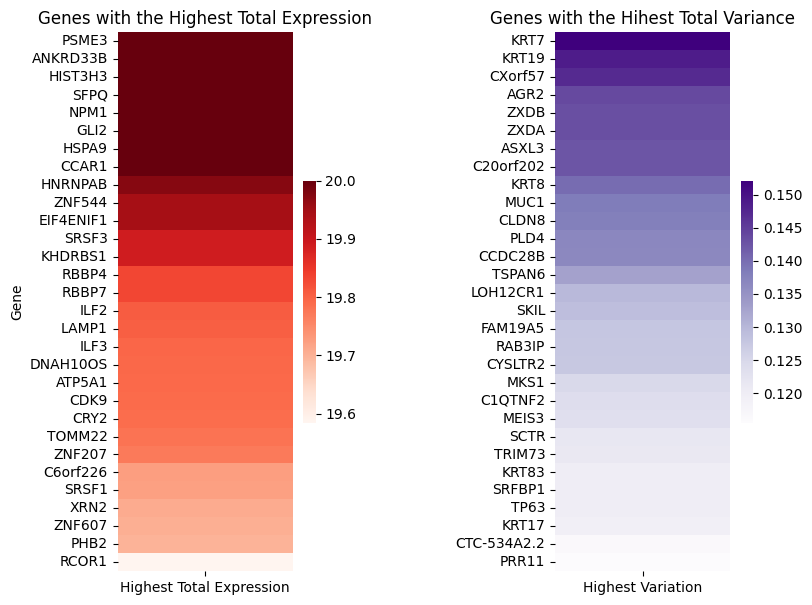

```python
#Determine the total expression of each gene by summing up all of the cancers
total_expression = average_expression.sum(axis=1)
total_expression = total_expression.sort_values(ascending=False)

#Create a new dataframe containing only the 30 highest expressing genes
total_expression_top_30 = pd.DataFrame(total_expression.iloc[:30])
total_expression_top_30.rename(columns = {0: "Highest Total Expression"}, inplace=True)

#Repeat the process to determine the genes with the highest variation
expression_var = average_expression.var(axis=1)
expression_var = expression_var.sort_values(ascending=False)
expression_var_top_30 = pd.DataFrame(expression_var.iloc[:30])
expression_var_top_30.rename(columns = {0: "Highest Variation"}, inplace=True)

#Generate a heatmap with 2 subplot showing the genes with the highest expressions and the highest variations
fig, axes = plt.subplots(1, 2, figsize = (1.5,7))
plt.subplots_adjust(wspace = 1, right = 4.5)
high = sns.heatmap(total_expression_top_30, cmap = 'Reds', cbar_kws={"shrink": 0.45}, ax = axes[0] )
var = sns.heatmap(expression_var_top_30, ax = axes[1], cmap = 'Purples', cbar_kws={"shrink": 0.45} )
axes[1].set_ylabel('')
axes[0].set_title('Genes with the Highest Total Expression')
axes[1].set_title('Genes with the Hihest Total Variance')
```

From these heatmaps, we can see that there are 8 genes which have ubiquitous expression, meaning that for all patients and for all cancer types, these 8 genes always had 'High' expression. PSME3 encodes a protein that is part of a complex celled the 'immunoproteosome'. It is well known that an important step in cancer pathogenesis is to escape surveillance and targeting by the immune system. It has recently been published that PSME3 upregulation (ie high expression) allows cancer cells to escape immune surveillance be reducing the expression of the multi-histocompatibility complex-1 (MHC-1) receptor present on the cell surface [link](https://www.ncbi.nlm.nih.gov/pmc/articles/PMC7458623/). In other words, by decreasing this MHC1 receptor on the surface of cancer cells, these cells have effectively become invisible to the body's immune system. Recent advances in personalized medicines such as the Chimeric Antigen Receptor T cell (CAR-T) therapy are designed to overcome the 'stealth' of cancer cells against the body's natural immune system. \ For genes exhibiting the highest variation, we observe a number of genes from the keratin family (KRT), which are gene that encode a number of structural proteins within a cell. Furthermore, it is well known that KRT19 is a biomarker for tumor metastasis [link](https://erc.bioscientifica.com/view/journals/erc/13/4/0131033.xml). These genes may also have specific and specialized cellular functions based on the normal tissue types from which these cancer cells evolved.

```python
#Clean up the datafram for the variation in gene expression for heatmap visualization
high_var_genes_top30 = pd.merge(expression_var_top_30, average_expression, left_index = True, right_index=True, how = "left")
high_var_genes_top30 = high_var_genes_top30.drop("Highest Variation", axis = 1)
high_var_genes_top30.set_axis(average_expression.columns, axis=1, inplace=True)
high_var_genes_top30.set_axis(average_expression.columns, axis=1, copy=False)
```

| Tumor Gene | Cancer Type breast cancer | Cancer Type carcinoid | Cancer Type cervical cancer | Cancer Type colorectal cancer | Cancer Type endometrial cancer | Cancer Type glioma | Cancer Type head and neck cancer | Cancer Type liver cancer | Cancer Type lung cancer | Cancer Type lymphoma | Cancer Type melanoma | Cancer Type ovarian cancer | Cancer Type pancreatic cancer | Cancer Type prostate cancer | Cancer Type renal cancer | Cancer Type skin cancer | Cancer Type stomach cancer | Cancer Type testis cancer | Cancer Type thyroid cancer | Cancer Type urothelial cancer |
| --- | --- | --- | --- | --- | --- | --- | --- | --- | --- | --- | --- | --- | --- | --- | --- | --- | --- | --- | --- | --- |
| KRT7 | 0.767000 | 0.000000 | 0.778333 | 0.167000 | 0.640000 | 0.000000 | 0.0000 | 0.416667 | 0.889167 | 0.000000 | 0.055833 | 0.916667 | 0.916667 | 0.467000 | 0.083333 | 0.166667 | 0.695000 | 0.000000 | 1.000000 | 0.889167 |
| KRT19 | 1.000000 | 1.000000 | 0.944167 | 0.970000 | 1.000000 | 0.055833 | 0.5825 | 0.416667 | 1.000000 | 0.000000 | 0.090909 | 0.972500 | 1.000000 | 0.788182 | 0.444167 | 0.468000 | 1.000000 | 0.027500 | 0.917500 | 1.000000 |
| CXorf57 | 1.000000 | 0.917500 | 0.444167 | 1.000000 | 0.910000 | 0.000000 | 0.2500 | 0.945000 | 0.636364 | 0.000000 | 0.000000 | 0.945000 | 0.967000 | 1.000000 | 0.639167 | 0.100000 | 0.963333 | 0.500000 | 1.000000 | 0.667273 |
| AGR2 | 0.889167 | 0.000000 | 0.555000 | 0.909091 | 0.849091 | 0.000000 | 0.0000 | 0.363636 | 0.750000 | 0.000000 | 0.000000 | 0.300000 | 0.722500 | 0.695000 | 0.027500 | 0.000000 | 1.000000 | 0.000000 | 0.502500 | 0.637273 |
| ZXDB | 1.000000 | 0.750000 | 0.735000 | 0.940000 | 0.868000 | 0.030000 | 0.1675 | 0.667500 | 0.516364 | 0.000000 | 0.082500 | 0.861667 | 0.833333 | 0.945000 | 0.139167 | 0.000000 | 0.835000 | 0.000000 | 0.780000 | 0.484545 |
| ZXDA | 1.000000 | 0.750000 | 0.735000 | 0.940000 | 0.868000 | 0.030000 | 0.1675 | 0.667500 | 0.516364 | 0.000000 | 0.082500 | 0.861667 | 0.833333 | 0.945000 | 0.139167 | 0.000000 | 0.835000 | 0.000000 | 0.780000 | 0.484545 |
| ASXL3 | 0.880000 | 0.332500 | 0.945000 | 0.834167 | 0.585833 | 0.000000 | 0.0000 | 0.200000 | 0.788182 | 0.000000 | 0.000000 | 0.723333 | 0.879091 | 0.425455 | 0.055000 | 0.134000 | 0.963333 | 0.083333 | 0.750000 | 0.788182 |
| C20orf202 | 1.000000 | 0.585000 | 0.910000 | 0.970000 | 0.890000 | 0.060000 | 0.5000 | 0.606364 | 0.768000 | 0.000000 | 0.000000 | 0.910000 | 1.000000 | 0.972500 | 0.393636 | 0.276667 | 0.917500 | 0.033000 | 1.000000 | 0.879091 |
| KRT8 | 1.000000 | 1.000000 | 0.778333 | 1.000000 | 0.862500 | 0.000000 | 0.3325 | 0.820000 | 0.972500 | 0.000000 | 0.000000 | 0.939091 | 0.820000 | 1.000000 | 0.472500 | 0.395455 | 0.697500 | 0.167500 | 1.000000 | 0.861667 |
| MUC1 | 0.916667 | 0.250000 | 1.000000 | 0.723333 | 0.972500 | 0.000000 | 0.7500 | 0.194167 | 0.834167 | 0.000000 | 0.000000 | 0.972500 | 0.818182 | 0.167000 | 0.778333 | 0.306667 | 1.000000 | 0.250000 | 0.750000 | 0.576364 |
| CLDN8 | 0.958750 | 0.917500 | 0.600000 | 1.000000 | 0.698182 | 0.000000 | 0.2500 | 0.367000 | 0.607273 | 0.000000 | 0.000000 | 1.000000 | 0.939091 | 0.940000 | 0.185556 | 0.055833 | 0.879091 | 0.333333 | 0.667500 | 0.472500 |
| PLD4 | 0.233000 | 0.000000 | 1.000000 | 0.760000 | 0.501000 | 0.000000 | 0.8325 | 0.484545 | 0.640000 | 0.000000 | 0.027500 | 0.778333 | 0.723333 | 0.000000 | 0.027500 | 0.970000 | 0.482222 | 0.030000 | 0.667500 | 0.800000 |
| CCDC28B | 0.909091 | 0.332500 | 0.667273 | 0.970000 | 0.778333 | 0.000000 | 0.4175 | 0.305833 | 0.800000 | 0.000000 | 0.000000 | 0.787273 | 0.945000 | 0.454545 | 0.055833 | 0.030000 | 0.940000 | 0.150909 | 0.750000 | 0.834167 |
| TSPAN6 | 0.529167 | 0.250000 | 0.972500 | 0.468000 | 0.945000 | 0.000000 | 0.5850 | 0.768000 | 0.890000 | 0.000000 | 0.110833 | 0.910000 | 0.972500 | 0.820000 | 0.417500 | 0.940000 | 0.972500 | 0.083333 | 0.165000 | 0.779167 |
| LOH12CR1 | 0.945000 | 0.835000 | 0.389167 | 0.583333 | 0.805833 | 0.000000 | 0.0000 | 0.278333 | 0.750833 | 0.000000 | 0.165833 | 0.500833 | 0.333636 | 1.000000 | 0.083333 | 0.060909 | 0.750000 | 0.000000 | 0.000000 | 0.111667 |
| SKIL | 1.000000 | 0.417500 | 0.888333 | 0.889167 | 0.789091 | 0.055000 | 0.8325 | 0.607273 | 0.860833 | 0.027500 | 0.083333 | 0.787273 | 0.967000 | 0.815556 | 0.332500 | 1.000000 | 1.000000 | 0.030000 | 0.667500 | 1.000000 |
| FAM19A5 | 0.199000 | 0.000000 | 0.788182 | 0.457500 | 0.060909 | 0.000000 | 1.0000 | 0.181818 | 0.555000 | 0.278333 | 0.120909 | 0.392727 | 0.638333 | 0.000000 | 0.060000 | 1.000000 | 0.181818 | 0.030000 | 0.890000 | 0.805833 |
| RAB3IP | 1.000000 | 0.752500 | 0.516364 | 0.972500 | 0.779167 | 0.000000 | 0.5000 | 0.583333 | 0.555833 | 0.000000 | 0.000000 | 0.637273 | 0.945000 | 0.972500 | 0.389167 | 0.027500 | 0.901000 | 0.110833 | 0.835000 | 0.534000 |
| CYSLTR2 | 0.834167 | 0.832500 | 0.445000 | 0.917500 | 0.668333 | 0.000000 | 0.1100 | 0.807500 | 0.607273 | 0.000000 | 0.030000 | 0.750833 | 0.940000 | 1.000000 | 0.585000 | 0.055833 | 0.861667 | 0.389167 | 1.000000 | 0.485455 |
| MKS1 | 1.000000 | 0.585000 | 0.471667 | 1.000000 | 0.611667 | 0.055833 | 0.5825 | 0.472500 | 0.467000 | 0.000000 | 0.000000 | 0.818182 | 0.867000 | 0.940000 | 0.364545 | 0.000000 | 0.945000 | 0.200000 | 0.917500 | 0.395455 |
| C1QTNF2 | 1.000000 | 0.667500 | 0.972500 | 1.000000 | 0.780000 | 0.030000 | 0.5000 | 0.667273 | 0.834167 | 0.000000 | 0.000000 | 0.890000 | 0.970000 | 1.000000 | 0.528333 | 1.000000 | 0.972500 | 0.333333 | 0.752500 | 0.972500 |
| MEIS3 | 0.967000 | 0.750000 | 0.453636 | 0.972500 | 0.555833 | 0.000000 | 0.0825 | 0.637273 | 0.485455 | 0.000000 | 0.030000 | 0.606364 | 0.933000 | 0.888889 | 0.082500 | 0.030000 | 0.852222 | 0.299000 | 0.335000 | 0.501000 |
| SCTR | 0.916667 | 0.333333 | 0.880000 | 0.704444 | 0.634000 | 0.000000 | 0.6700 | 0.300000 | 0.789091 | 0.000000 | 0.000000 | 0.910000 | 0.834000 | 0.333636 | 0.055833 | 0.852222 | 0.818182 | 0.083750 | 0.333333 | 0.768000 |
| TRIM73 | 1.000000 | 0.417500 | 0.545455 | 0.916667 | 0.555833 | 0.000000 | 0.1675 | 0.424545 | 0.606364 | 0.000000 | 0.233000 | 0.867000 | 0.900000 | 0.867000 | 0.180909 | 0.000000 | 0.889167 | 0.033000 | 0.556667 | 0.334286 |
| KRT83 | 0.303636 | 0.335000 | 0.867000 | 0.334167 | 0.516364 | 0.000000 | 1.0000 | 0.301000 | 0.639167 | 0.000000 | 0.000000 | 0.474167 | 0.777778 | 0.000000 | 0.055000 | 1.000000 | 0.467000 | 0.000000 | 0.223333 | 0.778889 |
| SRFBP1 | 1.000000 | 0.835000 | 0.752500 | 1.000000 | 0.729091 | 0.033000 | 0.7800 | 0.699091 | 0.850000 | 0.000000 | 0.111667 | 0.890000 | 0.917500 | 1.000000 | 0.332000 | 0.670000 | 0.945000 | 0.100000 | 0.776667 | 0.934000 |
| TP63 | 0.293333 | 0.082500 | 0.639167 | 0.082500 | 0.199000 | 0.027500 | 1.0000 | 0.073333 | 0.600000 | 0.027500 | 0.082500 | 0.247500 | 0.110833 | 0.060000 | 0.000000 | 1.000000 | 0.060000 | 0.303333 | 0.082500 | 0.972500 |
| KRT17 | 0.055833 | 0.000000 | 0.940000 | 0.111667 | 0.139167 | 0.000000 | 0.8900 | 0.273636 | 0.500833 | 0.000000 | 0.000000 | 0.334167 | 0.390000 | 0.060909 | 0.000000 | 0.910000 | 0.083333 | 0.000000 | 0.000000 | 0.800000 |
| CTC-534A2.2 | 0.834000 | 0.835000 | 0.388333 | 0.972500 | 0.669167 | 0.060000 | 0.2500 | 0.424545 | 0.530000 | 0.000000 | 0.055000 | 0.667273 | 0.933000 | 0.934000 | 0.267000 | 0.150909 | 0.806667 | 0.303636 | 1.000000 | 0.266000 |
| PRR11 | 0.121818 | 0.167500 | 0.945000 | 0.272727 | 0.668333 | 0.000000 | 0.9175 | 0.194167 | 0.606364 | 0.030000 | 0.066000 | 0.636364 | 0.726364 | 0.110000 | 0.120909 | 1.000000 | 0.424545 | 0.030000 | 0.250000 | 0.667500 |

To better visualize the gene expression variations, we create a heatmap to show the top 30 genes exhibiting the highest variance on the y axis, and the 20 cancer subtypes on the x axis.

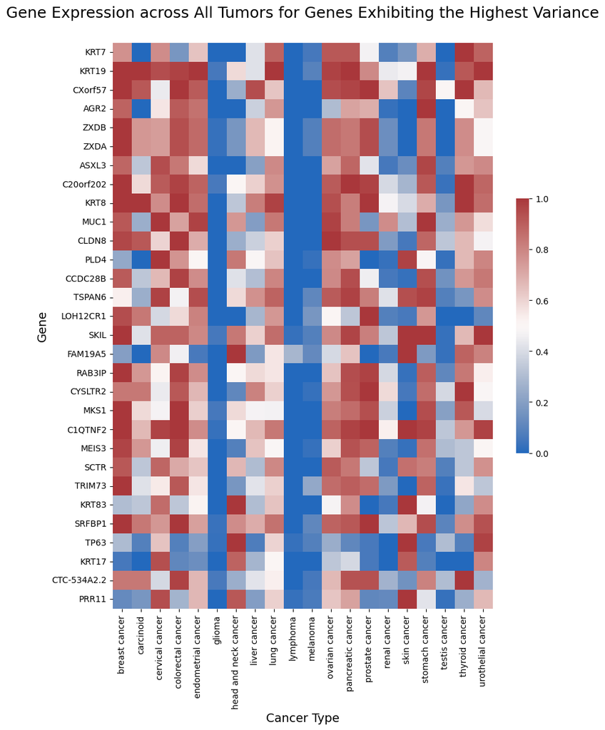

```python
fig, ax = plt.subplots(figsize = (10,12))
x_axis_labels = df["Tumor"].unique()
sns.heatmap(high_var_genes_top30, cmap='vlag', ax=ax, cbar_kws={"shrink": 0.45}, xticklabels = x_axis_labels)
ax.set_title("Gene Expression across All Tumors for Genes Exhibiting the Highest Variance", size=18, pad=30)
ax.set_xlabel("Cancer Type", size = 14)
ax.set_ylabel("Gene", size = 14)
```

From this heatmap, we observe that there is indeed a pattern to the gene expression variation. Lymphoma, melanoma, glioma and testis cancer havemuch lower average expression of these genes. Furthermore, with the data organized by variation of gene expression, we proceed to the next steps of our analysis.

## Purpose statement

A major challenge posed to machine learning and data sciences within the field of healthcare comes from the limitations of collected data. Particularly in the scenario of diagnosis, we are very interested in the concept of a model that accurately predicts, based on a given set of variables, if a disease state is present or not. This is often more broadly applicable in a setting involving disease screening; however within the realm of genetic cancer medicine, the expenses and relative novelty of performing such genetic testing is a barrier that typically results in data collection only after discovery of a confirmed cancer. Data available for research and machine learning within medicine is generally limited to "positives" leaving an unknown image of the negatives.

Our goal in this project is to train machine learning and statistical models to predict cancer type from gene expression data. That said, our data presents a particularity that requires us to think beyond the common machine learning workflows, notably, train/test splitting and feature selection. The challenge here is that we only have positive data to learn from; in other words, every data point is associated with a positive outcome (cancer type).

While we have the available option of treating a patient positive for skin cancer as a negative/unlabelled for a different cancer, we will still need to contend with the limitation that there is no profile within the dataset representing a true negative i.e. a randomly selected patient with no cancer.

In the field of machine learning, this scenario is known as positive unlabelled learning (PU learning) and is [a niche and growing topic of research in semi-supervised learning](https://link.springer.com/article/10.1007/s10994-020-05877-5).

## Possible approches to training with positive data

There are a few approaches to dealing with positive data and some are more relevant to our problem space than others.

1. **Data Augmentation:** It consists of artificially generating negative samples through data augmentation techniques. For example, we can introduce random noise or perturbations to the positive samples to create a diverse range of synthetic negative samples. This approach can help balance our dataset and improve the model's ability to generalize. While we will not be adding noise directly to our training data to obtain negative data, we will use a flavor of this technique to evaluate the efficiency of our models.
2. **Synthetic Minority Oversampling Technique (SMOTE)**: SMOTE is a popular technique used to generate synthetic samples for the minority class. It creates synthetic data points by interpolating between feature vectors of neighboring positive samples.SMOTE is usually applied to the positive data to create additional negative samples. This technique can help balance the dataset and provide the model with more diverse training examples. Given that we do not have any negative data at all, this approach will not be used here.
3. **Transfer Learning:** If obtaining negative samples is not feasible, one can leverage pre-trained models or transfer learning approaches. Pre-trained models are trained on large-scale datasets and can capture general patterns and features. Finding pretrained models could prove tricky, for that reason, this approach will not be used in this project.
4. **One-Class Classification**: One-class classification techniques are specifically designed for situations where only one class is available during training. These techniques learn the patterns and characteristics of the positive class and then identify anomalies or outliers as potential negatives. Examples of one-class classification algorithms include One-Class Support Vector Machines (OC-SVM) and Isolation Forest. These methods can be suitable for the scenario where we only have positive data and want to detect deviations from the positive class. These two models will be the center of our focus in this first section of training

# Introduction to the workflow for One-Class Classification

As mentioned above, the nature of the data dictates a workflow that will essentially consist of outlier detection which is a form of binary (outlier or inlier) classification. According to the [World Cancer Research Fund International](https://https://www.wcrf.org/cancer-trends/worldwide-cancer-data/), the top 5 cancers across both sexes in 2020 are Breast, Lung, colorectal, Prostate, and Stomach.

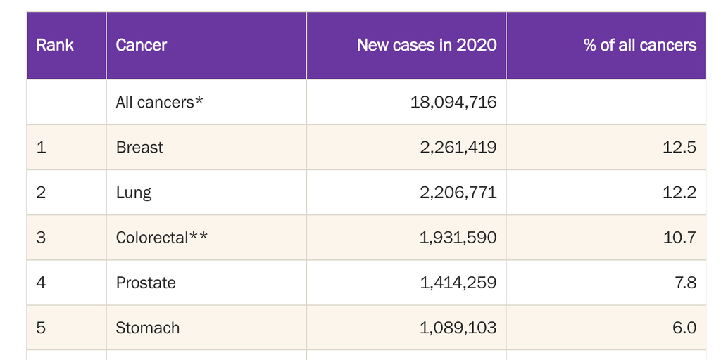

Credit & source: [World Cancer Research Fund International](https://www.wcrf.org/cancer-trends/worldwide-cancer-data/)

Because we do not have negative data, to evaluate the model for a given cancer type, we will add noise to the training data and use it to test the sensitivity of the models to small change in the training data. We will also combine the data for the other 3 cancers to test the accuracy of our training models. The quality of the model will be mostly decided on whether or not the model is able to classify the other cancer types as outliers.

# Descriptive Insight

```python
# rename Total patients
data = data.rename(columns={"Total patients":"total_patient","Count patients":"number_patient"})
# Compute the proportion of patients for each expression level and cancer type
data['Proportion'] = data["number_patient"] / data["total_patient"]
data.head()
```

|  | Gene | Gene name | Tumor | Level | number_patient | total_patient | Expression type | Proportion |
| --- | --- | --- | --- | --- | --- | --- | --- | --- |
| 0 | ENSG00000000003 | TSPAN6 | breast cancer | High | 1 | 12 | Staining | 0.083333 |
| 1 | ENSG00000000003 | TSPAN6 | breast cancer | Medium | 7 | 12 | Staining | 0.583333 |
| 2 | ENSG00000000003 | TSPAN6 | breast cancer | Low | 2 | 12 | Staining | 0.166667 |
| 3 | ENSG00000000003 | TSPAN6 | breast cancer | Not detected | 2 | 12 | Staining | 0.166667 |
| 4 | ENSG00000000003 | TSPAN6 | carcinoid | High | 0 | 4 | Staining | 0.000000 |

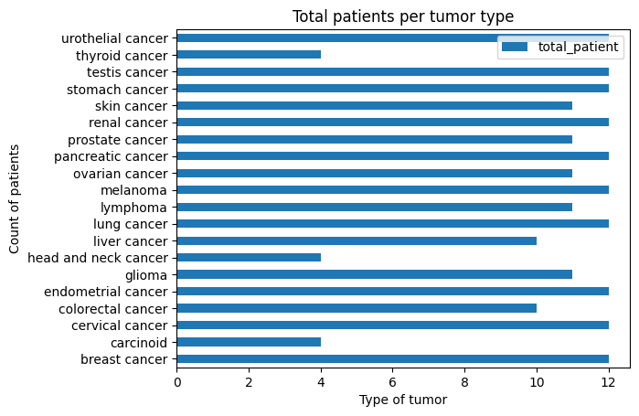

```python
# Taking a look at the number of patients per cancer
selection = pd.concat([data["Tumor"], data["total_patient"]],axis=1)
selection = selection.drop_duplicates(subset="Tumor")
selection.plot.barh(x="Tumor",y="total_patient",title="Total patients per tumor type",xlabel="Type of tumor",ylabel="Count of patients")
```

Our assumption is that the bigger/the more representative the sample size, the more we are able to generalize our training model to the specific cancer type. Thus, our hope is that the targetted cancers are representative enough in the dataset.

We get a few observations from the graph:

- The highest number of patient accros all patient groups is 12, this will be important to consider when evaluating the training results and their usefulness
- Most cancer types had approximately the same number of patients in the dataset
- Thyroid cancer, neck cancer, and carcinoid cancer have significantly fewer patients than the other cancer types
- Our target cancers are (luckily) also among cancers with the highest number of patients, at the exception of prostate cancer

We will now look at the number of genes per tumor type and per expression level

```python
data = data.drop(["Expression type","Gene","number_patient","total_patient"], axis=1)
data
```

|  | Gene name | Tumor | Level | Proportion |
| --- | --- | --- | --- | --- |
| 0 | TSPAN6 | breast cancer | High | 0.083333 |
| 1 | TSPAN6 | breast cancer | Medium | 0.583333 |
| 2 | TSPAN6 | breast cancer | Low | 0.166667 |
| 3 | TSPAN6 | breast cancer | Not detected | 0.166667 |
| 4 | TSPAN6 | carcinoid | High | 0.000000 |
| ... | ... | ... | ... | ... |
| 1306615 | FKSG52 | thyroid cancer | Not detected | 0.333333 |
| 1306616 | FKSG52 | urothelial cancer | High | 0.000000 |
| 1306617 | FKSG52 | urothelial cancer | Medium | 0.181818 |
| 1306618 | FKSG52 | urothelial cancer | Low | 0.000000 |
| 1306619 | FKSG52 | urothelial cancer | Not detected | 0.818182 |

1306620 rows × 4 columns

```python
# Select tumors and drop irrelevant column
tumors = data.drop(["Proportion"],axis=1)
tumors = tumors.groupby(["Tumor","Level"]).count()
tumors
```

| Tumor | Level | Gene name |
| --- | --- | --- |
| breast cancer | High | 16333 |
|  | Low | 16333 |
|  | Medium | 16333 |
|  | Not detected | 16333 |
| carcinoid | High | 16329 |
| ... | ... | ... |
| thyroid cancer | Not detected | 16333 |
| urothelial cancer | High | 16333 |
|  | Low | 16333 |
|  | Medium | 16333 |
|  | Not detected | 16333 |

80 rows × 1 columns

```
(array([ 0,  1,  2,  3,  4,  5,  6,  7,  8,  9, 10, 11, 12, 13, 14, 15, 16,
        17, 18, 19]),
 [Text(0, 0, 'breast cancer'),
```

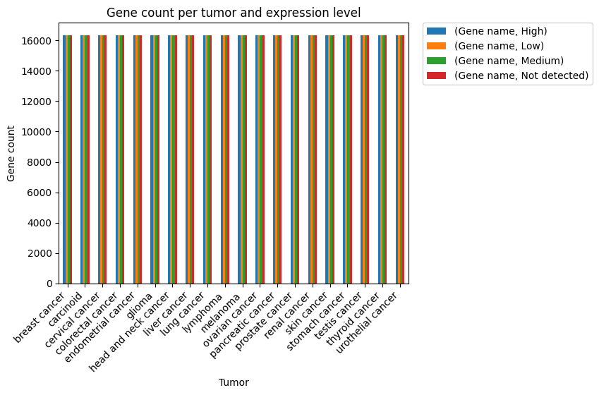

```python
tumors.unstack().plot.bar(title="Gene count per tumor and expression level",ylabel="Gene count")
plt.legend(bbox_to_anchor=(1.04, 1), borderaxespad=0)
plt.xticks(rotation=45,ha='right')
```

# A word on Feature Selection

```python
top_genes = ["KRT7", "KRT19", "CXorf57", "AGR2", "ZXDB", "ZXDA", "ASXL3", "C20orf202", "KRT8", "MUC1", "CLDN8", "PLD4", "CCDC28B", "TSPAN6", "LOH12CR1", "SKIL", "FAM19A5", "RAB3IP", "CYSLTR2", "MKS1", "C1QTNF2", "MEIS3", "C1QTNF2", "MEIS3", "SCTR", "TRIM73", "KRT83", "SRFBP1", "TP63", "KRT17", "CTC-534A2.2", "PRR11"]
```

```python
def update_level(cell):
    # turn levels into numerical normalized values
    levels = {"Not detected":0,"Low":0.33,"Medium":0.67,"High":1}
    return levels[cell]

top_genes_df = data.loc[data["Gene name"].isin(top_genes)]
updated_level=  pd.DataFrame(top_genes_df["Level"]).applymap(update_level)
top_genes_df["Level"]=updated_level
top_genes_df = top_genes_df.rename(columns={"Gene name":"gene_name"})
top_genes_df
```

|  | gene_name | Tumor | Level | Proportion |
| --- | --- | --- | --- | --- |
| 0 | TSPAN6 | breast cancer | 1.00 | 0.083333 |
| 1 | TSPAN6 | breast cancer | 0.67 | 0.583333 |
| 2 | TSPAN6 | breast cancer | 0.33 | 0.166667 |
| 3 | TSPAN6 | breast cancer | 0.00 | 0.166667 |
| 4 | TSPAN6 | carcinoid | 1.00 | 0.000000 |
| ... | ... | ... | ... | ... |
| 1259335 | CTC-534A2.2 | thyroid cancer | 0.00 | 0.000000 |
| 1259336 | CTC-534A2.2 | urothelial cancer | 1.00 | 0.000000 |
| 1259337 | CTC-534A2.2 | urothelial cancer | 0.67 | 0.200000 |
| 1259338 | CTC-534A2.2 | urothelial cancer | 0.33 | 0.400000 |
| 1259339 | CTC-534A2.2 | urothelial cancer | 0.00 | 0.400000 |

2400 rows × 4 columns

# Data preprocessing

To test the sensibility of our prediction models to noise, we create a function that adds noise to the training data for testing

```python
def get_noisy_data(data,epsilon=0.1):
  np_array = data.to_numpy() # turn dataframe to np array

  # Generate random noise with the same shape as 'data'
  column_names = data.columns.tolist()
  noise = np.random.normal(loc=0, scale=epsilon, size=data.shape)

  # Add the noise to the original data and remake a data frame from it
  noisy_data = pd.DataFrame(data + noise, columns=column_names)
  return noisy_data
```

A model is not of much use unless we can evaluate its accuracy. To that end, since we are performing outlier detection, we will use the [One vs Rest (OvR)](https://en.wikipedia.org/wiki/Multiclass_classification#:~:text=%2Drest-,One%2Dvs.,all%20other%20samples%20as%20negatives.) classification approach to generating negative data. To be clear, we are not training a formal OvR model, we are instead applying the core idea to splitting our data into testing and validation sets.

```python
def isolate_tumor(target):
    df = top_genes_df
    tumor_data = df.loc[df["Tumor"] == target]
    tumor_data = tumor_data.pivot_table(index=['gene_name'], columns='Level', values='Proportion')
    tumor_data = pd.DataFrame(tumor_data)

    return pd.DataFrame(tumor_data.T)

TRAINING_DATA_SIZE = 4
NEGATIVE_COLUMNS = 3

## we will combine the other 3 cancers as testing data
TESTING_DATA_SIZE = TRAINING_DATA_SIZE*NEGATIVE_COLUMNS
breast_cancer = isolate_tumor("breast cancer")
prostate_cancer = isolate_tumor("prostate cancer")
lung_cancer = isolate_tumor("lung cancer")
stomach_cancer = isolate_tumor("stomach cancer")


# The known outcomes of training and testing data
# outlier detection models return -1 for outliers and 1 for inliers
# but we want inliers to be 0 and outlier to be 1
test_Y = np.ones((TESTING_DATA_SIZE,)).astype(int) # conversion not need but it seems to silence some warnings
train_Y = np.zeros((TRAINING_DATA_SIZE,)).astype(int) # same reason as above

##Training sets

## prepare data for breast cancer
breast_ca_train_X = breast_cancer
stomach_ca_train_X = stomach_ca_train_X = stomach_cancer
lung_ca_train_X = lung_cancer
prostate_ca_train_X = prostate_cancer

breast_ca_test_Y = test_Y
breast_ca_train_X = breast_cancer
breast_ca_train_Y = train_Y
noisy_breast_ca = get_noisy_data(breast_cancer)
breast_ca_test_X = pd.concat([stomach_ca_train_X,lung_ca_train_X,prostate_ca_train_X])


## prepare data for lung cancer
noisy_lung_ca = get_noisy_data(lung_cancer)
lung_ca_test_X = pd.concat([stomach_cancer,breast_cancer,prostate_cancer])
# lung_ca_train_X = lung_cancer.iloc[:,0:TRAINING_DATA_SIZE]
lung_ca_test_Y = test_Y

lung_ca_train_Y = train_Y

## prepare data for prostate cancer
noisy_prostate_ca = get_noisy_data(prostate_cancer)
prostate_ca_test_X = pd.concat([stomach_cancer,breast_cancer,lung_cancer])
prostate_ca_test_Y = test_Y
# prostate_ca_train_X = prostate_cancer.iloc[:,0:TRAINING_DATA_SIZE]
prostate_ca_train_Y = train_Y

## prepare data for stomach cancer
noisy_stomach_ca = get_noisy_data(stomach_cancer)
stomach_ca_test_X = pd.concat([prostate_cancer,breast_cancer,lung_cancer])
stomach_ca_test_Y = test_Y
# stomach_ca_train_X = stomach_cancer.iloc[:,0:TRAINING_DATA_SIZE]
stomach_ca_train_Y = train_Y
```

# Training One Class Support Vector Machine (OC-SVM).

The OC-SVM model is a derivate of the Support Vector Machine model exclusively used for outlier or anomaly detection. Anomaly or outlier detection consists of training a model to detect whether an observation/data point is inconsistent with a known or expected pattern. At its core, the SVM model creates a line/vector or a hyperplane that separates the data into *poles*; this hyperplane or line will then decide the class of new observations.

## OC-SVM parameter Tuning

Below is a brief introduction of the parameters of this model

1. **kernel**: The kernel function specifies the type of hyperplane used to separate the data points. Common choices include 'linear', 'rbf' (Radial Basis Function), 'poly' (polynomial), and 'sigmoid'. Each kernel has its own characteristics and is suitable for different types of data. We choose rbf because it can handle non-linear decision boundaries effectively. It is suitable when there is no prior knowledge about the shape or distribution of the data.
2. **nu**: This parameter controls the trade-off between the number of training examples considered outliers and the number of support vectors. It represents an upper bound on the fraction of training errors and a lower bound on the fraction of support vectors. A smaller value of nu allows more training examples to be classified as outliers.
3. **gamma**: It is a parameter specific to the 'rbf', 'poly', and 'sigmoid' kernels. It defines the influence of a single training example, with higher values leading to tighter and more complex decision boundaries. Higher values of gamma can result in overfitting, while lower values can cause underfitting.
4. **degree**: This parameter is specific to the 'poly' kernel and represents the degree of the polynomial function. It determines the flexibility of the decision boundary. Higher values of degree can lead to overfitting.
5. coef0: It is a parameter used by the 'poly' and 'sigmoid' kernels. It controls the independent term in the decision function. It affects the model's ability to fit nonlinear patterns in the data.

Because we chose rbf, we will not need to use `degree`and `coef0`. However, we need to be cautious about choosing the appropriate value for the 'gamma' parameter, as a high value can lead to overfitting

## Creating the models

### Finetuning for One Classs Support Vector Machine

The ideal approach would be to finetune the models for each cancer type, however, this turns out to induce a heavy computational cost. For that reason, we will do the finetuning for a single svm model and apply the optimal parameters to the rest of the cancer types.

```python
def format_prediction(p):
   if p==-1:
     return 1 # outlier
   return 0 #inlier

# vectorize the above function
pred_format = np.vectorize(format_prediction)
# For varying nu
def train_and_get_metrics(train_X,train_Y):
  # Create a range of gammas to find the optimal value
  # we will do parameter with the breast cancer data

  nus = np.linspace(0.00001,0.999,12)
  trained_models = [OneClassSVM(nu=nu,kernel="rbf",gamma="auto").fit(train_X) for nu in nus]
  train_predictions = pred_format([cross_val_predict(m, train_X, cv=4) for m in trained_models])
  train_accuracies = [accuracy_score(train_Y, pred) for pred in train_predictions]
  return (nus,train_accuracies)
```

The implication of setting gamma to 'auto' is that the algorithm will calculate the gamma value automatically, taking into account the dimensionality of the input data . This can be useful because the appropriate value of gamma depends on the scale of the input features. By automatically adjusting the gamma value, the algorithm aims to adapt to the characteristics of the data without requiring manual tuning.

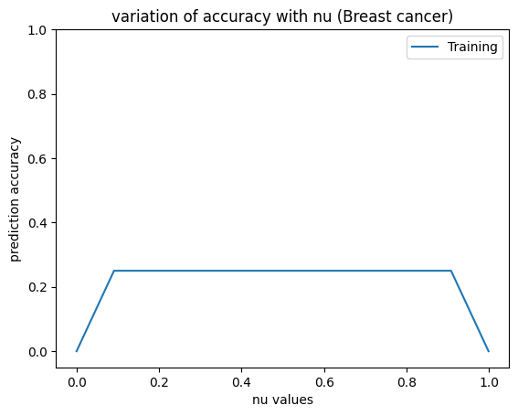

```python
## Plotting the results (nu)
nus,train_accs = train_and_get_metrics(breast_ca_train_X,breast_ca_train_Y)
fig,ax = plt.subplots()
ax.plot(nus,train_accs,label="Training")
ax.set_xlabel("nu values")
ax.set_ylabel("prediction accuracy")
ax.set_ylim(-0.05,1)
ax.set_title("variation of accuracy with nu (Breast cancer)")
ax.legend()
```

From this graph, It appears that that training accuracy plateaus at 25% with nu in the interval [0.1, 0.9].

The default value of nu is 0.5. Since we do not see any benefit in changing it, we maintain the default.

### Finetuning for Isolation Forest

Before we dive into finetuning, here is an overview of the Isolation Forest model.

[Isolation Forest](https://scikit-learn.org/stable/modules/generated/sklearn.ensemble.IsolationForest.html) is an unsupervised learning algorithm designed for anomaly detection. Instead of building trees using subsets of the data (as is the case with Random Forest), Isolation Forest constructs isolation trees based on random splits of the feature space.

Below are the parameters:

It now appears that will not need any manual tuning of the model parameters for isolation forest.

# Training Models

### Training for OC-SVM

```python
# function that takes a model, trains it and return training and testing metrics
def train_model(model,train_X,train_Y,test_X,test_Y):
  training_model = model.fit(train_X) # We do not fit training_Y because this is anomaly detection, the class is automatically assumed.
  test_pred = pred_format(training_model.predict(test_X))
  train_pred = pred_format(training_model.predict(train_X))
  test_acc = accuracy_score(test_Y, test_pred)
  train_acc = accuracy_score(train_Y, train_pred)
  return (train_acc,test_acc)

svm_breast_ca = OneClassSVM(nu=0.5,kernel="rbf",gamma='auto')
svm_lung_ca = OneClassSVM(nu=0.5,kernel="rbf",gamma='auto')
svm_prostate_ca = OneClassSVM(nu=0.5,kernel="rbf",gamma='auto')
svm_stomach_ca = OneClassSVM(nu=0.5,kernel="rbf",gamma='auto')

train_acc_breast_ca,test_acc_breast_ca = train_model(svm_breast_ca,breast_ca_train_X,breast_ca_train_Y,breast_ca_test_X,breast_ca_test_Y)
train_acc_lung_ca,test_acc_lung_ca = train_model(svm_lung_ca,lung_ca_train_X,lung_ca_train_Y,lung_ca_test_X,lung_ca_test_Y)
train_acc_prostate_ca,test_acc_prostate_ca = train_model(svm_prostate_ca,prostate_ca_train_X,prostate_ca_train_Y,prostate_ca_test_X,prostate_ca_test_Y)
train_acc_stomach_ca,test_acc_stomach_ca = train_model(svm_stomach_ca,stomach_ca_train_X,stomach_ca_train_Y,stomach_ca_test_X,stomach_ca_test_Y)

training_res = [train_acc_breast_ca,train_acc_lung_ca,train_acc_prostate_ca,train_acc_stomach_ca]
testing_res = [test_acc_breast_ca,test_acc_lung_ca,test_acc_prostate_ca,test_acc_stomach_ca]

result = pd.DataFrame({"training":training_res,"testing":testing_res},index=["Breast cancer","Lung cancer","Prostate cancer","Stomach cancer"])
result
```

|  | training | testing |
| --- | --- | --- |
| Breast cancer | 0.50 | 0.166667 |
| Lung cancer | 0.25 | 0.916667 |
| Prostate cancer | 0.50 | 0.166667 |
| Stomach cancer | 0.50 | 0.416667 |

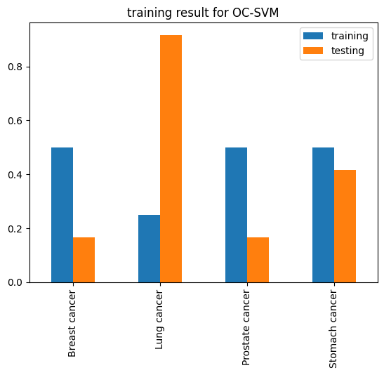

```python
result.plot.bar(title="training result for OC-SVM")
```

## Testing OC-SVM with noisy data

```python
noisy_test_breast_ca = svm_breast_ca.predict(noisy_breast_ca)
noisy_test_lung_ca = svm_lung_ca.predict(noisy_lung_ca)
noisy_test_prostate_ca = svm_prostate_ca.predict(noisy_prostate_ca)
noisy_test_stomach_ca = svm_stomach_ca.predict(noisy_stomach_ca)



training_res = [train_acc_breast_ca,train_acc_lung_ca,train_acc_prostate_ca,train_acc_stomach_ca]
testing_res = [test_acc_breast_ca,test_acc_lung_ca,test_acc_prostate_ca,test_acc_stomach_ca]

result = pd.DataFrame({"Breast":noisy_test_breast_ca,"Prostate":noisy_test_prostate_ca,"Lung":noisy_test_lung_ca,"Stomach":noisy_test_stomach_ca})


# replace numerical prediction outcomes with names
def format_test_res(val):
  if val==-1:
    return "outlier"
  return "inlier"

result = result.applymap(format_test_res)
result
```

|  | Breast | Prostate | Lung | Stomach |
| --- | --- | --- | --- | --- |
| 0 | outlier | outlier | outlier | outlier |
| 1 | outlier | outlier | outlier | outlier |
| 2 | inlier | inlier | outlier | outlier |
| 3 | outlier | outlier | outlier | inlier |

### Training for Isolation Forest

```python
### training for Isolation Forest
if_breast_ca = IsolationForest(random_state=35)
if_lung_ca = IsolationForest(random_state=35)
if_prostate_ca = IsolationForest(random_state=35)
if_stomach_ca = IsolationForest(random_state=35)

train_acc_breast_ca,test_acc_breast_ca = train_model(if_breast_ca,breast_ca_train_X,breast_ca_train_Y,breast_ca_test_X,breast_ca_test_Y)
train_acc_lung_ca,test_acc_lung_ca = train_model(if_lung_ca,lung_ca_train_X,lung_ca_train_Y,lung_ca_test_X,lung_ca_test_Y)
train_acc_prostate_ca,test_acc_prostate_ca = train_model(if_prostate_ca,prostate_ca_train_X,prostate_ca_train_Y,prostate_ca_test_X,prostate_ca_test_Y)
train_acc_stomach_ca,test_acc_stomach_ca = train_model(if_stomach_ca,stomach_ca_train_X,stomach_ca_train_Y,stomach_ca_test_X,stomach_ca_test_Y)

training_res = [train_acc_breast_ca,train_acc_lung_ca,train_acc_prostate_ca,train_acc_stomach_ca]
testing_res = [test_acc_breast_ca,test_acc_lung_ca,test_acc_prostate_ca,test_acc_stomach_ca]

result = pd.DataFrame({"training":training_res,"testing":testing_res},index=["Breast cancer","Lung cancer","Prostate cancer","Stomach cancer"])
result
```

|  | training | testing |
| --- | --- | --- |
| Breast cancer | 0.75 | 0.250000 |
| Lung cancer | 1.00 | 0.250000 |
| Prostate cancer | 0.75 | 0.166667 |
| Stomach cancer | 0.75 | 0.250000 |

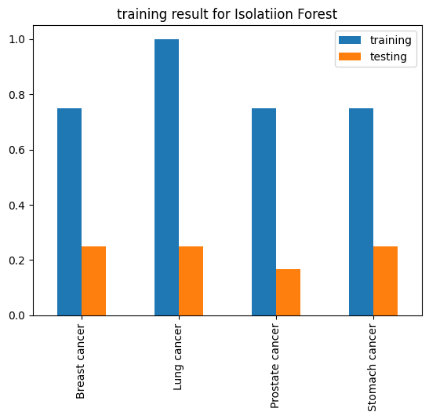

```python
result.plot.bar(title="training result for Isolatiion Forest")
```

## Testing Isolation Forest with Noisy data

```python
noisy_test_breast_ca = if_breast_ca.predict(noisy_breast_ca)
noisy_test_lung_ca = if_lung_ca.predict(noisy_lung_ca)
noisy_test_prostate_ca = if_prostate_ca.predict(noisy_prostate_ca)
noisy_test_stomach_ca = if_stomach_ca.predict(noisy_stomach_ca)



training_res = [train_acc_breast_ca,train_acc_lung_ca,train_acc_prostate_ca,train_acc_stomach_ca]
testing_res = [test_acc_breast_ca,test_acc_lung_ca,test_acc_prostate_ca,test_acc_stomach_ca]

result = pd.DataFrame({"Breast":noisy_test_breast_ca,"Prostate":noisy_test_prostate_ca,"Lung":noisy_test_lung_ca,"Stomach":noisy_test_stomach_ca})


# replace numerical prediction outcomes with names
def format_test_res(val):
  if val==-1:
    return "outlier"
  return "inlier"

result = result.applymap(format_test_res)
result
```

|  | Breast | Prostate | Lung | Stomach |
| --- | --- | --- | --- | --- |
| 0 | inlier | inlier | inlier | inlier |
| 1 | inlier | inlier | inlier | inlier |
| 2 | inlier | inlier | inlier | inlier |
| 3 | outlier | outlier | outlier | outlier |

# Analysis, Comparison, and Interpretation of the Results of Outlier Dectection

Looking at the results of Isolation Forest and One Class Support Vector Machine, we can see that, overall, the training accuracy is significantly higher than the testing accuracy, this is due to overfitting. In the case of of our data, overfitting is not a surprising outcome because our models suffer from what is known in the field of machine learning as *P-greater-than-N scenarios*. This terminology refers to cases where we have more features than observations; in our case, the training data has 30 features (genes) against only 4 observations (rows). To address this, one might be tempted to add more rows to the data, but that is no mean feat in this particular situation due to the difficulty of obtaining cancer diagnosis data.

We can also notice that the testing accuracy for lung cancer is higher than its training accuracy with OC-SVM. This suggests that the model underfitted the data. This is most likely due to our decision to finetune all the models using only breast cancer. With more computing resources, we could eliminate this by selecting the model parameters per model and per cancer.

One surprising result is that OC-SVM classification seems to be more sensitive to noise compared to Isolation Forest, this appears in the prediction outcome of the noisy data. With 10% noise added to the testing data, Isolation forest successfully classified most observations except for the row where gene expression is high. This seems to suggest that the genes with high expression are critical to the decision of the model, hence a slight variation in them greatly influences the outcome of the prediction. The choice between the two outlier detection models would greatly depend on the level of tolerance for noise in the domain of the specific problem at hand. In our problem space, medical expertise is required to determine how variations in gene expression affect cancer outcomes.

It is important to reemphasize the fact that machine learning with positive unlabelled data is still in its early days and is not well established yet. In addition to the P-greater-than-N weakness of our models, we made one implicit assumption that might justify the low accuracies. By using the same genes(features) to predict all cancers, we are assuming that gene expressions are atomically related to one cancer type at a time. In practice, it may be the case that that many cancers share the same level of expression, in that case, using the same genes to predict those cancers becomes tricky. Furthermore, our initial data has over 16000 genes, due to limited computing power, we decided to forgo proper feature selection methods such as Principal Component Analysis (PCA) to simply use the top 30 genes with the highest variance. In that process, we might have eliminated some genes that are actually critical to some cancer types.

# Neural Network Model

This portion of this project will explore another alternative form of machine learning workflow within the scope of positive unlabelled learning (PUL). We will approach by semi-supervised training of a sequential neural network to serve our goal of binary classification using the limited positive samples (breast cancer) alongside a mixed set of unlabelled/assumed negative data taken from the other samples.

The goal of this model will be to observe its accuracy in predicting the binary state of breast cancer or no breast cancer when given a genetic profile of a patient.

As mentioned in the previous discussion regarding the limitations of feature selection with this dataset, we will approach the feature selection aspect of this model by training on the 30 genes displaying highest variance in expression across all cancers based on the previously seen heatmap. The reason to select for highest variance is to hopefully maximize on available differences for the model to train as unlabelled.

## Data Processing

To generate the base dataframe that we will extract individual cancer data from, the number values of patients per cancer is dropped and replaced with a column containing proportion of patients with a particular gene expression level for each individual cancer.

```python
df_prune = data.loc[data["Gene name"].isin(["KRT7", "KRT19", "CXorf57", "AGR2", "ZXDB", "ZXDA", "ASXL3", "C20orf202", "KRT8", "MUC1", "CLDN8", "PLD4", "CCDC28B", "TSPAN6", "LOH12CR1", "SKIL", "FAM19A5", "RAB3IP", "CYSLTR2", "MKS1", "C1QTNF2", "MEIS3", "C1QTNF2", "MEIS3", "SCTR", "TRIM73", "KRT83", "SRFBP1", "TP63", "KRT17", "CTC-534A2.2", "PRR11"])]

base = df_prune
```

The following function is used to isolate data set per cancer

```python
def isolate(base, target, result):
    new_set = base.loc[base["Tumor"] == target]
    new_set.set_index(['Gene name','Proportion', 'Level'], append=True)
    t_Ca = new_set.pivot_table(index=['Gene name'], columns='Level', values='Proportion')
    # t_Ca.assign(Test = 1)
    t_Ca = pd.DataFrame(t_Ca)
    t_Ca_t = t_Ca.T
    t = t_Ca_t.assign(Test = result)
    return t
```

## Exclusions from the unlabelled set

Two of the cancers within the data set(carcinoid, colorectal) contain expression levels of various gene conformations that are not found within our targeted positive data or lack certain gene profiles that are found within breast cancer. Due to the imbalance in our limited positive data vs. unlabelled data, we may choose to exclude the two incomplete sets from our unlabelled pool in favour of focusing on profiles that are compatible. We will use complete profiles to be treated as unlabelled for training and testing purposes first to run the model.

```python
eca = isolate(base, "endometrial cancer", 0)
luca = isolate(base, "lung cancer", 0)
paca = isolate(base, "pancreatic cancer", 0)
stca = isolate(base, "stomach cancer", 0)
teca = isolate(base, "testis cancer", 0)
ova = isolate(base, "ovarian cancer", 0)
lyca = isolate(base, "lymphoma", 0)
gca = isolate(base, "glioma", 0)
hnca = isolate(base, "head and neck cancer", 0)

sca = isolate(base, "skin cancer", 0)
lca = isolate(base, "liver cancer", 0)
tca = isolate(base, "thyroid cancer", 0)
mca = isolate(base, "melanoma", 0)
rca = isolate(base, "renal cancer", 0)
pca = isolate(base, "prostate cancer", 0)
cca = isolate(base, "cervical cancer", 0)
uca = isolate(base, "urothelial cancer", 0)
BCA = isolate(base, "breast cancer", 1)

Total_unlabelled_cancers = [sca, lca, tca, mca, rca, pca, cca, uca, hnca, gca, lyca, ova, teca, stca, paca, luca, eca]
unlabelled = [sca, lca, mca, rca, pca]
unlabelled_set2 = [cca, uca, hnca, gca, lyca]
unlabelled_set3 = [ova, teca, stca, paca, luca, eca]

v_size = len(BCA.columns) - 1

unlabelled[0]
```

| Gene name Level | AGR2 | ASXL3 | C1QTNF2 | C20orf202 | CCDC28B | CLDN8 | CTC-534A2.2 | CXorf57 | CYSLTR2 | FAM19A5 | ... | RAB3IP | SCTR | SKIL | SRFBP1 | TP63 | TRIM73 | TSPAN6 | ZXDA | ZXDB | Test |
| --- | --- | --- | --- | --- | --- | --- | --- | --- | --- | --- | --- | --- | --- | --- | --- | --- | --- | --- | --- | --- | --- |
| High | 0.0 | 0.0 | 1.0 | 0.000000 | 0.000000 | 0.000000 | 0.000000 | 0.0 | 0.000000 | 1.0 | ... | 0.000000 | 0.666667 | 1.0 | 0.0 | 1.0 | 0.0 | 0.818182 | 0.0 | 0.0 | 0 |
| Low | 0.0 | 0.0 | 0.0 | 0.500000 | 0.090909 | 0.000000 | 0.272727 | 0.1 | 0.000000 | 0.0 | ... | 0.083333 | 0.111111 | 0.0 | 0.0 | 0.0 | 0.0 | 0.000000 | 0.0 | 0.0 | 0 |
| Medium | 0.0 | 0.2 | 0.0 | 0.166667 | 0.000000 | 0.083333 | 0.090909 | 0.1 | 0.083333 | 0.0 | ... | 0.000000 | 0.222222 | 0.0 | 1.0 | 0.0 | 0.0 | 0.181818 | 0.0 | 0.0 | 0 |
| Not detected | 1.0 | 0.8 | 0.0 | 0.333333 | 0.909091 | 0.916667 | 0.636364 | 0.8 | 0.916667 | 0.0 | ... | 0.916667 | 0.000000 | 0.0 | 0.0 | 0.0 | 1.0 | 0.000000 | 1.0 | 1.0 | 0 |

4 rows × 31 columns

## Preparing train and test data sets

```python
import warnings
warnings.filterwarnings('ignore')
#Warning method import due to notification for future depreciation of append method

def generate_X(dataset):
    out = pd.DataFrame()
    for i in dataset:
        temp_set = i.iloc[:,0:v_size]
        out = out.append([temp_set])
    return out

def generate_Y(i):
    return i.iloc[:,v_size]

X_unlabelled = generate_X(unlabelled)

X_positive = BCA.assign(Test = 1).iloc[:,0:v_size]

Y_unlabelled = pd.concat([generate_Y(i) for i in unlabelled])

Y_positive = BCA.iloc[:,v_size]


X_set = pd.concat([X_positive, X_unlabelled])
Y_set = pd.concat([Y_positive, Y_unlabelled])

print(X_set.head())
print(Y_set)
```

```
Gene name         AGR2     ASXL3  C1QTNF2  C20orf202   CCDC28B  CLDN8  \
Level
High          0.833333  0.636364      1.0        1.0  0.909091  0.875
Low           0.000000  0.000000      0.0        0.0  0.000000  0.000
Medium        0.083333  0.363636      0.0        0.0  0.000000  0.125
Not detected  0.083333  0.000000      0.0        0.0  0.090909  0.000
High          0.000000  0.000000      1.0        0.0  0.000000  0.000

Gene name     CTC-534A2.2  CXorf57   CYSLTR2  FAM19A5  ...     PRR11  RAB3IP  \
Level                                                  ...
High                  0.6      1.0  0.666667      0.1  ...  0.000000     1.0
Low                   0.1      0.0  0.000000      0.3  ...  0.000000     0.0
Medium                0.3      0.0  0.250000      0.0  ...  0.181818     0.0
Not detected          0.0      0.0  0.083333      0.6  ...  0.818182     0.0
High                  0.0      0.0  0.000000      1.0  ...  1.000000     0.0

Gene name         SCTR  SKIL  SRFBP1      TP63  TRIM73    TSPAN6  ZXDA  ZXDB
Level
High          0.833333   1.0     1.0  0.000000     1.0  0.083333   1.0   1.0
Low           0.083333   0.0     0.0  0.888889     0.0  0.166667   0.0   0.0
Medium        0.083333   0.0     0.0  0.000000     0.0  0.583333   0.0   0.0
Not detected  0.000000   0.0     0.0  0.111111     0.0  0.166667   0.0   0.0
High          0.666667   1.0     0.0  1.000000     0.0  0.818182   0.0   0.0

[5 rows x 30 columns]
Level
High            1
Low             1
Medium          1
Not detected    1
High            0
Low             0
Medium          0
Not detected    0
High            0
Low             0
Medium          0
Not detected    0
High            0
Low             0
Medium          0
Not detected    0
High            0
Low             0
Medium          0
Not detected    0
High            0
Low             0
Medium          0
Not detected    0
Name: Test, dtype: int64
```

The data sets as generated for independent (X) and response (Y) variables are encoded with breast cancer results = 0 for false and 1 for true. X variables will also remain within range [0,1] as a proportion value of gene expression. The imbalance in positive/unlabelled can be observed in Y_Set.

```python
X_total_unlabelled = generate_X(Total_unlabelled_cancers)
Y_total_unlabelled = pd.concat([generate_Y(i) for i in Total_unlabelled_cancers])

XT_set = pd.concat([X_positive, X_total_unlabelled])
YT_set = pd.concat([Y_positive, Y_total_unlabelled])

X_2_unlabelled = generate_X(unlabelled_set2)
X_3_unlabelled = generate_X(unlabelled_set3)
Y_2_unlabelled = pd.concat([generate_Y(i) for i in unlabelled_set2])
Y_3_unlabelled = pd.concat([generate_Y(i) for i in unlabelled_set3])

X2_set = pd.concat([X_positive, X_2_unlabelled])
Y2_set = pd.concat([Y_positive, Y_2_unlabelled])
X3_set = pd.concat([X_positive, X_3_unlabelled])
Y3_set = pd.concat([Y_positive, Y_3_unlabelled])
```

For the purposes of managing the limitations of small sized positive data, we will create partitions within the training and testing sets. All train sets will ensure a minimum of 3 positive data points. The labelling for the prepared datasets will be as follows:

- X1, X2, X3: Each approximately 1/3 proportion of all valid unlabelled gene expressions to better correct imbalance of positive vs. unlabelled pools. Each of these X1/X2/X3 will continue to contain all positive data points.
- XT: Total collection of all valid unlabelled gene expressions with all positive data

```python
X_train, X_test, Y_train, Y_test = train_test_split(X_set, Y_set, test_size=0.2, random_state=1)
XT_train, XT_test, YT_train, YT_test = train_test_split(XT_set, YT_set, test_size=0.2, random_state=1)

X2_train, X2_test, Y2_train, Y2_test = train_test_split(X2_set, Y2_set, test_size=0.2, random_state=1)
X3_train, X3_test, Y3_train, Y3_test = train_test_split(X3_set, Y3_set, test_size=0.2, random_state=1)
```

## Creating the sequential model for binary classification

The sequential model allows us to specify a neural network defined by passing thorugh input to output through neural layers in order of the desired sequence. For the purposes of defining a binary classifier, we will define the final layer to output to be a single node with sigmoid activation, a function that will map it's input values to either 0 or 1 making it suitable for binary and logistic regression type problems.

Below is a description of the model parameters:

## Metrics and Model Layers

The below two functions will assess the model for overall accuracy and specific binary accuracy metrics, they will be assigned b_model for accuracy metrics and ba_model for binary accuracy. The determination of number of layers in a model will vary depending on the data. Generally more layers will represent more biases and weights, increasing accuracy for the cost of computation as well as increasing risks of overfitting. As there is no standard or formula for determining layers, this models parameters will be generated from the result of experimentation.

The function below is used to reset model weights during the experimenting phase

```python
def reinitialize(model):
    for l in model.layers:
        if hasattr(l,"kernel_initializer"):
            l.kernel.assign(l.kernel_initializer(tf.shape(l.kernel)))
        if hasattr(l,"bias_initializer"):
            l.bias.assign(l.bias_initializer(tf.shape(l.bias)))
        if hasattr(l,"recurrent_initializer"):
            l.recurrent_kernel.assign(l.recurrent_initializer(tf.shape(l.recurrent_kernel)))
```

```python
def create_binaryclass_model():
    model = Sequential()
    model.add(Dense(4, input_shape=(v_size,), activation='sigmoid'))
    model.add(Dense(8, activation='relu'))
    model.add(Dense(1, activation='sigmoid'))

    model.compile(loss='binary_crossentropy', optimizer='adam', metrics=['accuracy'])
    return model

def create_binaryclass_model_acc():
    model = Sequential()
    model.add(Dense(4, input_shape=(v_size,), activation='sigmoid'))
    model.add(Dense(8, activation='relu'))
    model.add(Dense(1, activation='sigmoid'))

    model.compile(loss='binary_crossentropy', optimizer='adam', metrics=['binary_accuracy'])
    return model
```

```python
b_model = create_binaryclass_model()
ba_model = create_binaryclass_model_acc()
```

## Model fitting

Much like the previous model creation, fitting and determining epoch vs. batch_size are also dependent on the dataset and were obtained here through experimentation.

We will fit the models with 25 epochs at batch size 5.

```python
b_history = b_model.fit(X_train, Y_train, epochs=25, batch_size=5, verbose = 0)
ba_history = ba_model.fit(X_train, Y_train, epochs=25, batch_size=5, verbose = 0)
```

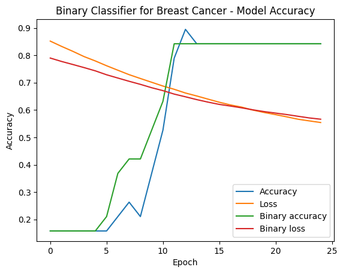

```python
plt.plot(b_history.history['accuracy'])
plt.plot(b_history.history['loss'])
plt.plot(ba_history.history['binary_accuracy'])
plt.plot(ba_history.history['loss'])
plt.title('Binary Classifier for Breast Cancer - Model Accuracy')
plt.ylabel('Accuracy')
plt.xlabel('Epoch')
plt.legend(['Accuracy', 'Loss', 'Binary accuracy', 'Binary loss'], loc='lower right')
plt.show()
```

```python
b_total_model = create_binaryclass_model()
b_total_history = b_total_model.fit(XT_train, YT_train, epochs=25, batch_size=5, verbose = 0)
```

```python
ba_total_model = create_binaryclass_model_acc()
ba_total_history = ba_total_model.fit(XT_train, YT_train, epochs=25, batch_size=5, verbose = 0)
```

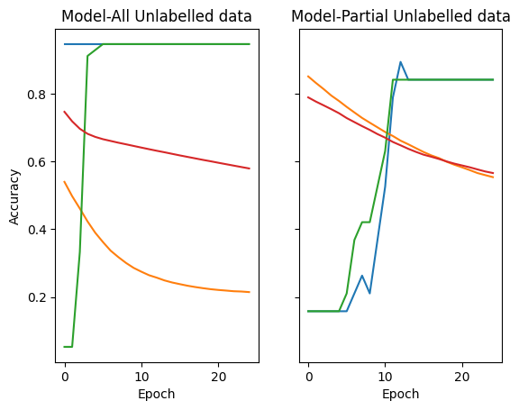

```python
fig,ax = plt.subplots(nrows = 1, ncols = 2, sharey = True)

ax[0].plot(b_total_history.history['accuracy'])
ax[0].plot(b_total_history.history['loss'])
ax[0].plot(ba_total_history.history['binary_accuracy'])
ax[0].plot(ba_total_history.history['loss'])
ax[0].set_title('Model-All Unlabelled data')
ax[0].set_ylabel('Accuracy')
ax[0].set_xlabel('Epoch')

ax[1].plot(b_history.history['accuracy'])
ax[1].plot(b_history.history['loss'])
ax[1].plot(ba_history.history['binary_accuracy'])
ax[1].plot(ba_history.history['loss'])
ax[1].set_title('Model-Partial Unlabelled data')
ax[1].set_xlabel('Epoch')
```

Below, we use b_partial to represent a model that has been trained on all 3 partitioned sets of unlabelled/positive data. Since all 3 sets each contain a randomized split of the positive data, the expectation is to expose the model to all our available unlabelled points while reducing instability as a result of disproportionally small amounts of positive data.

```python
b_partials = create_binaryclass_model()
b_partials.summary()
```

```
Model: "sequential_51"
_________________________________________________________________
 Layer (type)                Output Shape              Param #
=================================================================
 dense_153 (Dense)           (None, 4)                 124

 dense_154 (Dense)           (None, 8)                 40

 dense_155 (Dense)           (None, 1)                 9

=================================================================
Total params: 173
Trainable params: 173
Non-trainable params: 0
_________________________________________________________________
```

```python
b_partials.fit(X_train, Y_train, epochs=5, batch_size=5)
```

```
<keras.callbacks.History at 0x7fc8cdb00c40>
```

```python
b_partials.fit(X2_train, Y2_train, epochs=5, batch_size=5)
```

```
<keras.callbacks.History at 0x7fc8cda53a90>
```

```python
b_partials.fit(X3_train, Y3_train, epochs=5, batch_size=5)
```

```
<keras.callbacks.History at 0x7fc8ce0a2fe0>
```

```python
score = b_partials.evaluate(X_set, Y_set, verbose=0)
print('Test loss:', score[0])
print('Test accuracy:', score[1])
```

```
Test loss: 0.5191190838813782
Test accuracy: 0.8333333134651184
```

# Analysis and Discussion of results

In the case of our current unlabelled data pool, this total dataset has an approximate prior positive probability of: $$ Positive Prior = {4 observations \over 16333 genes \times 4 observations} = 6.123\mathrm{e}{-5} $$ which is well below a minimum recommendation of ideally >0.01 prior positive class[1] to conduct training on.

To test our machine learning models, we adjust for the size of unlabelled data through selection of 30 highest variance features giving us a minimum of:

$$ Positive Prior = {4 observations \over 30 genes \times 4 observations} = 0.0333 $$

From observing the results of the neural network, we can see that although we are able to train the model toward a higher test accuracy within ranges of 80%, we can still see some limitations from using small samples of positively labelled data. For example in the 3 models trained, (one which was trained on 1/3 of unlabelled samples, one trained fully using unlabelled samples and one trained using all unlabelled samples but in 3 partitioned iterations), we may observe large discrete jumps in accuracy variation per epoch during training. This is likely attributed to potential overfitting due to small amounts of available positive samples for use in training and testing.

From these models, we can observe some potential future changes and directions to move in to further the applications of machine learning in genetic medicine.

One such potential direction would be to apply a randomized sample method similar to the noise generation in the section we test SVM to the positive data points. This would add to rows (observations) to provide better balance between positive/unlabelled data.

This model could then be better described as a probabilistic classifier which would return the probability of cancer based on genetic profile rather than the binary. Since we are able to use the ratio of positive over observations as a prior positive probability, we could apply Bayes probability:

\begin{equation} P(Ca|\textbf{x}) = P(Ca ) \frac{P(\textbf{x} |Ca)}{P(\textbf{X})} \end{equation}

for probability of cancer(Ca) given feature(x), and normalize using probability of generated row values being part of the set of true positives.

Citations:

1. Eric B. Baum, David Haussler; What Size Net Gives Valid Generalization?. Neural Comput 1989; 1 (1): 151–160. doi: https://doi.org/10.1162/neco.1989.1.1.151

## Conclusion

We present here a project that aims to use regressions and neural network tools to create a pipeline for the analysis of gene expression levels in different cancer types. We employed a variety of methods in order to compare and contrast the strengths and shortcomings of each approach.